# Bayesian multivariate spatial autoregression in “nimble”

Sudipto Banerjee

2023-11-29

The following OpenBUGS code is written for GMCAR full model, where phi_1|phi_2 ~ CAR(alpha_1, tau_1) with its conditional mean beta_1 + (eta_0 I + eta_1 W) (phi_2 - beta_2) and phi_2 ~ CAR(alpha_2, tau_2) with its mean beta_2. Here the conditioning order is phi_1 given phi_2 and phi_2.

Remove all objects from R workspace—good programming practice and can help debug your code better.

```r
rm(list = ls())
```

```r
source("../src/data_prep_multivariate_areal.R")
```

[output not shown]

```
## To access larger datasets in this package, install the spDataLarge
## package with: `install.packages('spDataLarge',
## repos='https://nowosad.github.io/drat/', type='source')`
```

```
## Spherical geometry (s2) switched off
```

```
## although coordinates are longitude/latitude, st_intersects assumes that they
## are planar
```

Load “nimble” and “coda” packages

```r
library(nimble)
library(coda)
```

Read the nimble code

```r
spCode <- nimbleCode({

    for(i in 1:N) {
        Y1[i] ~ dnorm(mu1[i], tau1)
        Y2[i] ~ dnorm(mu2[i], tau2)
        mu1[i] <- inprod(X[i,1:p], beta1[1:p]) + w1[i]
        mu2[i] <- inprod(X[i,1:p], beta2[1:p]) + w2[i]

        mu[i] <- eta_0*w2[i] + eta_1*inprod(A[i,1:N], w2[1:N]) #To be used in CAR model mean for w1 | w2

        y1Fit[i] ~ dnorm(mu1[i], tau1)
        y2Fit[i] ~ dnorm(mu2[i], tau2)
    }

    w2[1:N] ~ dcar_proper(zeros[1:N], adj=adj[1:L], num=num[1:N], tau=tau1Sp, gamma=gamma1)
    w1[1:N] ~ dcar_proper(mu[1:N], adj=adj[1:L], num=num[1:N], tau=tau2Sp, gamma=gamma2)

    tau1Sp ~ dgamma(0.01, 0.01)
        sigma1Sp <- 1/sqrt(tau1Sp)
    tau2Sp ~ dgamma(0.01, 0.01)
    sigma2Sp <- 1/sqrt(tau2Sp)

        for (i in 1:p) {
        beta1[i] ~ dflat()
        beta2[i] ~ dflat()
    }
        tau1 ~ dgamma(0.001, 0.001)
        sigma1 <- 1/sqrt(tau1)
    tau2 ~ dgamma(0.001, 0.001)
        sigma2 <- 1/sqrt(tau2)

    eta_0 ~ dnorm(0, 0.01)
    eta_1 ~ dnorm(0, 0.01)

    gamma1 ~ dunif(0, 0.999)       # avoid improper CAR to maintain identifiability
    gamma2 ~ dunif(0, 0.999)
})
```

Initial values

```r
nimbleInits <- list(beta1=rep(0,times=p), beta2=rep(0,times=p), tau1=1, tau2=1, eta_0=0.3, eta_1=0.3, gamma1=0.5, gamma2=0.5, w1=rep(0, times=N), w2=rep(0, times=N), tau1Sp=1, tau2Sp=1, y1Fit=rep(0, times=N), y2Fit=rep(0, times=N))
```

Define the model parameters to be recognized by the nimble model

```r
model_parameters = c("beta1", "beta2", "sigma1", "sigma2", "sigma1Sp", "sigma2Sp", "eta_0", "eta_1", "gamma1", "gamma2", "w1", "w2", "y1Fit", "y2Fit")
```

Include the nimble adjacency formats to nimbleData.

```r
adjInfo <- as.carAdjacency(A)
L <- length(adjInfo$adj)
nimbleConstants <- c(nimbleConstants, adjInfo, L=L)
```

Set the following variables:

```r
n_iter = 11000 ## Number of iterations
n_chains = 1 ## Number of different chains
n_burn = 1000 ## Number of initial runs ("burn" period) for MCMC to converge.
```

Create the nimbleModel and run MCMC

```r
rModel <- nimbleModel(code = spCode, constants=nimbleConstants, data=nimbleData)
```

```
## Defining model
```

```
##   [Note] 'weights' is provided in 'constants' but not used in the model code and is being ignored.
```

```
## Building model
```

```
## Setting data and initial values
```

```
## Running calculate on model
##   [Note] Any error reports that follow may simply reflect missing values in model variables.
```

```
## Checking model sizes and dimensions
```

```
##   [Note] This model is not fully initialized. This is not an error.
##          To see which variables are not initialized, use model$initializeInfo().
##          For more information on model initialization, see help(modelInitialization).
```

```r
mcmc.out <- nimbleMCMC(model = rModel, nchains=n_chains, inits=nimbleInits, niter = n_iter, nburnin=n_burn, monitor=model_parameters)
```

```
## Compiling
##   [Note] This may take a minute.
##   [Note] Use 'showCompilerOutput = TRUE' to see C++ compilation details.
```

```
## running chain 1...
```

```
## |-------------|-------------|-------------|-------------|
## |-------------------------------------------------------|
```

Extract posterior samples:

```r
samps <- as.matrix(mcmc.out)
dim(samps)
```

```
## [1] 10000   244
```

Obtain medians and 95% credible intervals for these samples

```r
credibleIntervals <- t(apply(samps, 2, function(x){quantile(x, c(0.50, 0.025, 0.975))}))
```

Extract credible intervals for specific variable(s):

```r
CI_beta1 <- credibleIntervals[grep("beta1", rownames(credibleIntervals)),]
CI_beta1
```

```
##                50%       2.5%     97.5%
## beta1[1] 25.808263 18.4500895 32.881857
## beta1[2]  1.343327  0.8719051  1.833064
```

```r
CI_beta2 <- credibleIntervals[grep("beta2", rownames(credibleIntervals)),]
CI_beta2
```

```
##                 50%       2.5%     97.5%
## beta2[1] 1.08714416 0.42191300 1.7571868
## beta2[2] 0.07091077 0.02530798 0.1133336
```

```r
CI_sigma <- credibleIntervals[grep("sigma", rownames(credibleIntervals)),]
CI_sigma
```

```
##                50%      2.5%     97.5%
## sigma1   6.7460269 4.5717672 8.5558244
## sigma1Sp 0.2395640 0.1082473 0.9598889
## sigma2   0.7439472 0.5960182 0.9174509
## sigma2Sp 1.8243293 0.1333764 8.9336187
```

```r
CI_eta <- credibleIntervals[grep("eta_", rownames(credibleIntervals)),]
CI_eta
```

```
##            50%       2.5%    97.5%
## eta_0 8.499161 -11.674057 21.14571
## eta_1 2.011039  -6.884695 17.51193
```

```r
CI_w1 <- credibleIntervals[grep("w1", rownames(credibleIntervals)),]
CI_w2 <- credibleIntervals[grep("w2", rownames(credibleIntervals)),]

CI_y1Fit <- credibleIntervals[grep("y1Fit", rownames(credibleIntervals)),]
CI_y2Fit <- credibleIntervals[grep("y2Fit", rownames(credibleIntervals)),]
```

Prepare to plot spatial random effects on a map. Load some packages

```r
library(maps)
library(ggplot2)
library(RColorBrewer)
library(dplyr)
library(tidyr)
library(classInt)
```

Extract map of California from “maps” library.

```r
caCounty = map("county","california", fill=TRUE, plot=FALSE)
countyID <- sapply(strsplit(caCounty$names, ","), function(x) x[2])
caCountySF <- st_as_sf(caCounty)
```

Plot posterior median of model fitted values for lung cancer on the map. Plot raw data next to it.

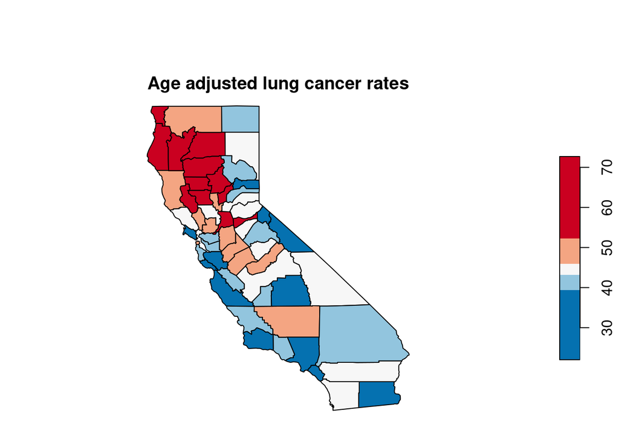

```r
y1FitPosteriorMedians <- CI_y1Fit[,grep("50%", colnames(CI_y1Fit))]
caCountySF$ModelFitted <- y1FitPosteriorMedians
caCountySF$ObsData <- Y1
brksModelFitted = quantile(caCountySF$ModelFitted, c(0, 0.2, 0.4, 0.6, 0.8, 1))
brksObsData = quantile(caCountySF$ObsData, c(0, 0.2, 0.4, 0.6, 0.8, 1))

colorPalette = rev(brewer.pal(5,"RdBu"))

par(mfrow=c(1,2), oma = c(0,0,4,0) + 0.1, mar = c(0,0,1,0) + 0.1)
plot(caCountySF["ObsData"], pal = colorPalette, breaks = brksObsData, main = "Age adjusted lung cancer rates")
```

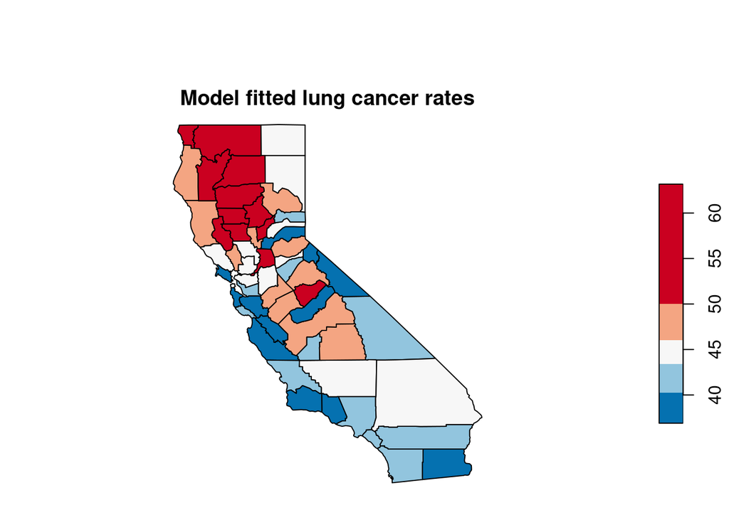

```r
plot(caCountySF["ModelFitted"], pal = colorPalette, breaks = brksModelFitted, main = "Model fitted lung cancer rates")
```

Plot posterior median of model fitted values for larynx cancer on the map. Plot raw data next to it.

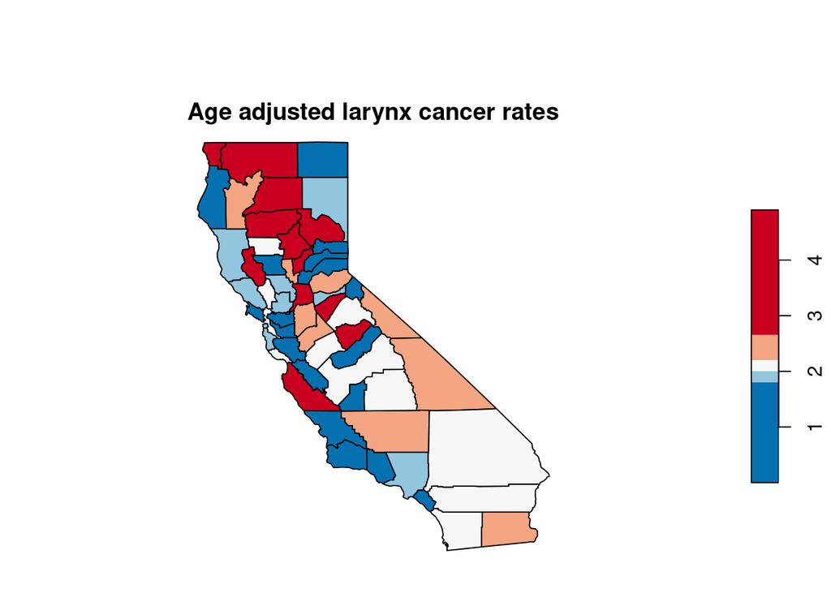

```r
y2FitPosteriorMedians <- CI_y2Fit[,grep("50%", colnames(CI_y2Fit))]
caCountySF$ModelFitted <- y2FitPosteriorMedians
caCountySF$ObsData <- Y2
brksModelFitted = quantile(caCountySF$ModelFitted, c(0, 0.2, 0.4, 0.6, 0.8, 1))
brksObsData = quantile(caCountySF$ObsData, c(0, 0.2, 0.4, 0.6, 0.8, 1))

colorPalette = rev(brewer.pal(5,"RdBu"))

par(mfrow=c(1,2), oma = c(0,0,4,0) + 0.1, mar = c(0,0,1,0) + 0.1)
plot(caCountySF["ObsData"], pal = colorPalette, breaks = brksObsData, main = "Age adjusted larynx cancer rates")
```

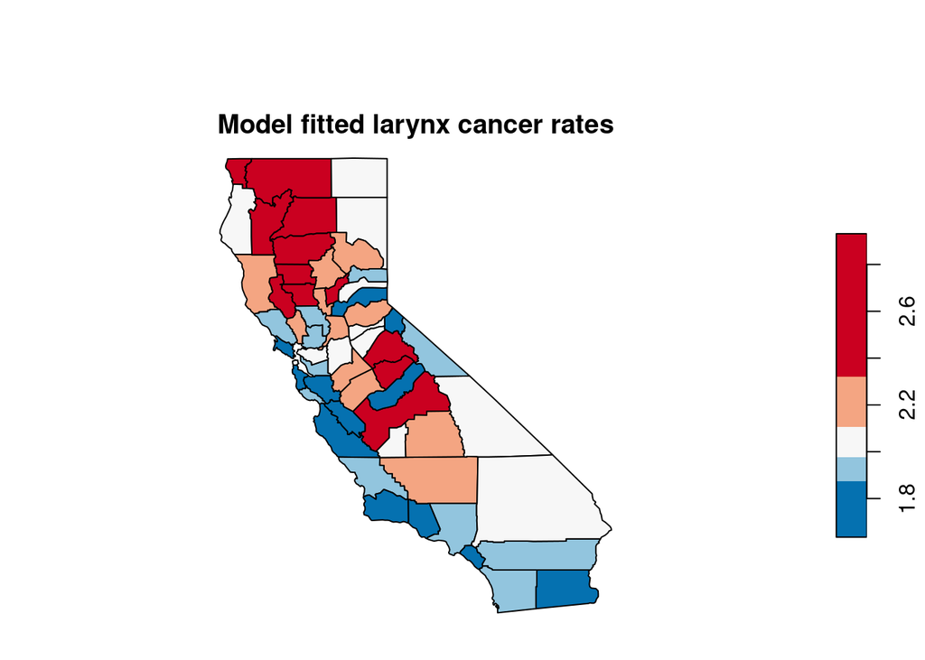

```r
plot(caCountySF["ModelFitted"], pal = colorPalette, breaks = brksModelFitted, main = "Model fitted larynx cancer rates")
```

Plot posterior median of spatial residuals for lung and larynx cancers on the map.

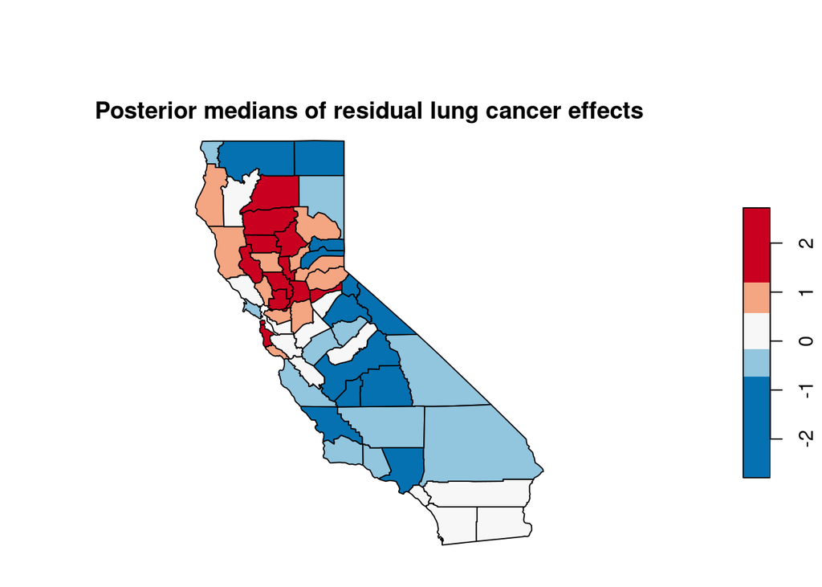

```r
w1PosteriorMedians <- CI_w1[,grep("50%", colnames(CI_w1))]
w2PosteriorMedians <- CI_w2[,grep("50%", colnames(CI_w2))]

caCountySF$w1PosteriorMedians <- w1PosteriorMedians
caCountySF$w2PosteriorMedians <- w2PosteriorMedians

brks1 = quantile(w1PosteriorMedians, c(0, 0.2, 0.4, 0.6, 0.8, 1))
brks2 = quantile(w2PosteriorMedians, c(0, 0.2, 0.4, 0.6, 0.8, 1))

colorPalette = rev(brewer.pal(5,"RdBu"))

par(mfrow=c(1,2), oma = c(0,0,4,0) + 0.1, mar = c(0,0,1,0) + 0.1)
plot(caCountySF["w1PosteriorMedians"], pal = colorPalette, breaks = brks1, main = "Posterior medians of residual lung cancer effects")
```

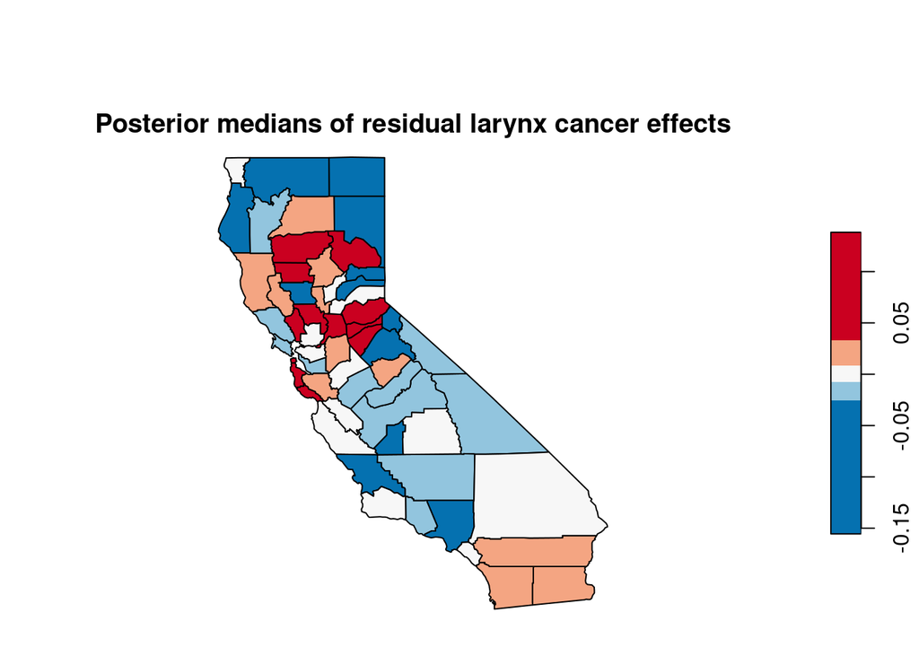

```r
plot(caCountySF["w2PosteriorMedians"], pal = colorPalette, breaks = brks2, main = "Posterior medians of residual larynx cancer effects")
```